# Prediction Assignment

Nithya Kalyani

## Overview of Data Set

This report is based on the Weight Lifting Exercises dataset which contains data about “how (well)” an exercising activity was performed by the person wearing the device. Six young health participants were asked to perform one set of 10 repetitions of the Unilateral Dumbbell Biceps Curl in five different fashions: exactly according to the specification (Class A), throwing the elbows to the front (Class B), lifting the dumbbell only halfway (Class C), lowering the dumbbell only halfway (Class D) and throwing the hips to the front (Class E). Class A corresponds to the specified execution of the exercise, while the other 4 classes correspond to common mistakes.

The goal is to predict the manner in which the subjects did the exercise. This is the “classe” variable in the training set. Our outcome “classe” is a five level factor variable.

```r
#Load training data
training <- read.csv("https://d396qusza40orc.cloudfront.net/predmachlearn/pml-training.csv")
#Variable to be predicted
table(training$classe)
```

```
##
##    A    B    C    D    E
## 5580 3797 3422 3216 3607
```

## Creation of Training & Validation Data sets

The given training dataset has been split 70% into training and 30% into validation sets. This training set will be used for building the model and applied on the validation set to arrive at the out of sample error estimate.

```r
#Split training data into training and validation sets
inbuild <- createDataPartition(training$classe,p=0.7,list=FALSE)
validationset <- training[-inbuild,]
trainset <- training[inbuild,]
```

## Selection of Predictors

The dataset contains 159 variables excluding ‘classe’ which we want to predict. The variables with missing values have been removed, variables with blank values have also been removed. Also, the variables containing user names, time data and serial numbers have also been excluded.

```r
#Remove variables with missing values
nas <- apply(trainset,2,function(x) sum(is.na(x)))
cols <- names(trainset[,nas==0])
trsub <- trainset[,cols]
#Remove character variables
cla <- sapply(trsub,class)
traindf <- trsub[,cla!="character"]
traindf <- traindf[,-c(1:4)]
```

Thus, we have 52 predictor variables after excluding the blank, missing and unnecessary variables in the above steps.

```r
#Final training data set
trset <- cbind(traindf,classe = trsub$classe)
```

## Model Selection

```r
#Check correlation of predictors
predictors <- trset[,-53]
M <- abs(cor(predictors))
diag(M) <- 0
length(which(M>0.8))
```

```
## [1] 38
```

As the predictors are highly correlated, random forest model is chosen for predicting this classification problem.

## Building Model

Before building the random forest model, the tuning parameter, no. of predictors ‘m’ to be randomly chosen by the model while building each tree is set equal to square root of no. of predictors. Cross validation has been used with the default number of folds, i.e 10. Also, to reduce the computation time, parallel processing has been enabled.

Various values of ‘number of predictors (m)’ have been specified for tuning the model.

```r
#Fitting model
set.seed(3443)
mtry <- sqrt(ncol(trset))
tunegrid <- expand.grid(.mtry=c(2,4,mtry,mtry+1,mtry+2))
fitcontrol <- trainControl(method = "cv",allowParallel = TRUE)
fit_rf <- train(classe~.,method="rf",data=trset,
                trControl = fitcontrol,tuneGrid=tunegrid)
```

## Applying Model on Validation Set

The random forest model is applied on the validation set to check how well it predicts on a dataset other than the data set using which it was built.

```r
#Predict on the validation set using the fit model
columns <- names(trset)
vset <- validationset[,columns]
pred_rf <- predict(fit_rf,vset)
```

## Results of Prediction on Validation Set

Below summary of the random forest model, shows the number of predictors for which the model produces highest accuracy.

```r
print(fit_rf)
```

```
## Random Forest
##
## 13737 samples
##    52 predictor
##     5 classes: 'A', 'B', 'C', 'D', 'E'
##
## No pre-processing
## Resampling: Cross-Validated (10 fold)
## Summary of sample sizes: 12365, 12364, 12362, 12364, 12364, 12363, ...
## Resampling results across tuning parameters:
##
##   mtry     Accuracy   Kappa
##   2.00000  0.9916997  0.9894990
##   4.00000  0.9930099  0.9911573
##   7.28011  0.9944661  0.9929995
##   8.28011  0.9943934  0.9929077
##   9.28011  0.9940295  0.9924475
##
## Accuracy was used to select the optimal model using the largest value.
## The final value used for the model was mtry = 7.28011.
```

### Comparison of Predicted and Actual Values in Validation Set

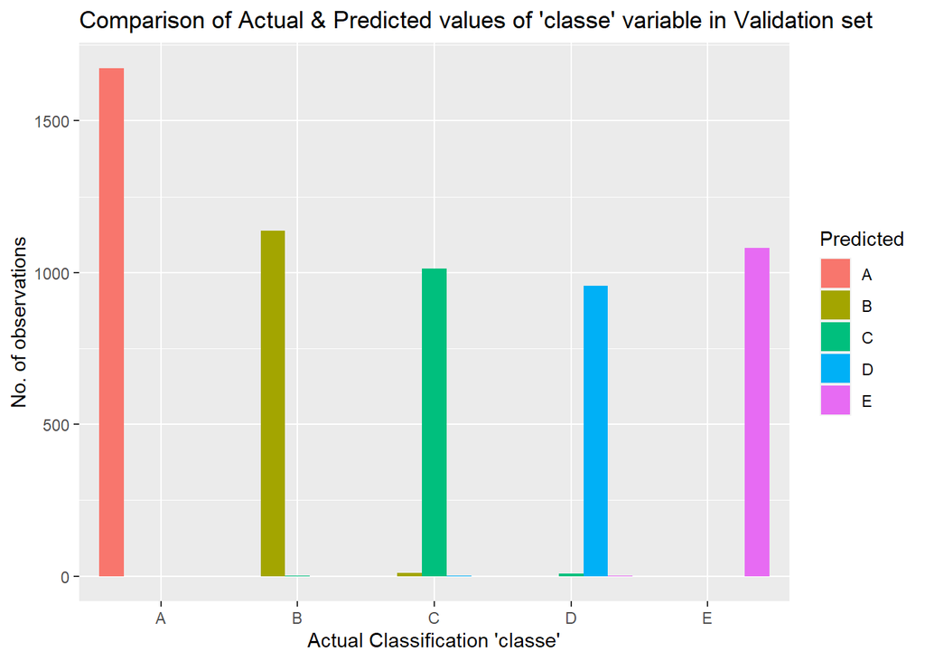

### Accuracy Estimate of Model

The model has a very high overall accuracy as well as class accuracy, as seen from below output.

```r
#Accuracy achieved by the model
confusionMatrix(pred_rf,as.factor(vset$classe))
```

```
## Confusion Matrix and Statistics
##
##           Reference
## Prediction    A    B    C    D    E
##          A 1674    0    0    0    0
##          B    0 1137   11    0    0
##          C    0    2 1013    7    0
##          D    0    0    2  956    0
##          E    0    0    0    1 1082
##
## Overall Statistics
##
##                Accuracy : 0.9961
##                  95% CI : (0.9941, 0.9975)
##     No Information Rate : 0.2845
##     P-Value [Acc > NIR] : < 2.2e-16
##
##                   Kappa : 0.9951
##
##  Mcnemar's Test P-Value : NA
##
## Statistics by Class:
##
##                      Class: A Class: B Class: C Class: D Class: E
## Sensitivity            1.0000   0.9982   0.9873   0.9917   1.0000
## Specificity            1.0000   0.9977   0.9981   0.9996   0.9998
## Pos Pred Value         1.0000   0.9904   0.9912   0.9979   0.9991
## Neg Pred Value         1.0000   0.9996   0.9973   0.9984   1.0000
## Prevalence             0.2845   0.1935   0.1743   0.1638   0.1839
## Detection Rate         0.2845   0.1932   0.1721   0.1624   0.1839
## Detection Prevalence   0.2845   0.1951   0.1737   0.1628   0.1840
## Balanced Accuracy      1.0000   0.9980   0.9927   0.9956   0.9999
```

### Error Estimate of The Model

The below plot shows that the random forest model achieves an error rate of less than 0.05.

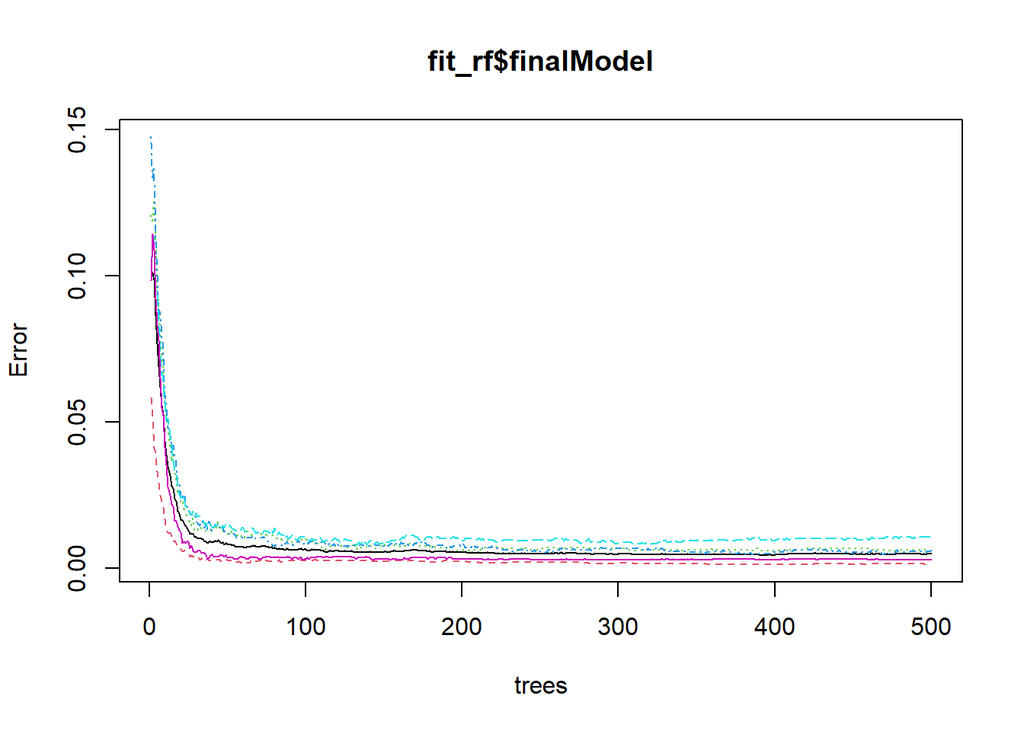